# Investigating Class docs

Phoebe Guinn

1 July 2019

## Language and Intersectionality of Gender and Class

### Loading Into Dataframe

```r
library(LexisNexisTools)
library(quanteda)
```

```r
library(stringr)
library(ggplot2)

file_names <- list.files(pattern = ".txt",
                        path = "~/Capstone/Extreme Class Articles",
                        full.names = TRUE, recursive = TRUE, ignore.case = TRUE) %>%
  append(list.files(pattern = "Angela Rayner|Rebecca Long-Bailey|Margaret Jay|Tessa Jowell",
                    path = "~/Capstone/Female Cabinet Articles",
                    full.names = TRUE, recursive = TRUE, ignore.case = TRUE)) %>%
  append(list.files(pattern = "Alan Johnson|Bob Ainsworth|Tristram Hunt|Hilary Benn|Chuka Umunna",
                    path = "~/Capstone/Male Cabinet Articles",
                    full.names = TRUE, recursive = TRUE, ignore.case = TRUE))

mp_names <- str_extract(file_names, "([^/]+$)") %>%
  gsub("\\.TXT", "", .)

mp_class <- c("wc", "wc", "uc", "wc", "wc", "uc", "wc", "wc", "uc",
              "wc", "uc", "wc", "wc", "uc", "uc", "uc")


class_frame <- data.frame()
for (i in 1:length(file_names)) {
  LNToutput <- lnt_read(x = file_names[i], extract_paragraphs = FALSE, verbose = F)
  temp <- data.frame(LNToutput@articles)
  temp$mp <- rep(mp_names[i], nrow(temp))
  temp$class <- rep(mp_class[i], nrow(temp))
  class_frame <- rbind(class_frame, temp)
}
```

[output not shown]

```r
table(class_frame$class)
```

```
##
##   uc   wc
## 2333  969
```

```r
table(class_frame$mp)
```

```
##
##        Alan Johnson       Angela Rayner       Bob Ainsworth
##                 291                 103                  28
##        Chuka Umunna         David Lammy      Dennis Skinner
##                 566                 288                 185
##    Fiona MacTaggart         Hilary Benn        Jess Philips
##                  23                 342                   8
##       Laura Pidcock      Margaret Hodge        Margaret Jay
##                  13                 311                  45
## Rebecca Long-Bailey      Richard Burgon        Tessa Jowell
##                  37                  16                 628
##       Tristram Hunt
##                 418
```

### Finding Key Features

-Just keep features within wc dictionary: HGI -Following keys decided through literature review Virtue: 719 words indicating an assessment of moral approval or good fortune, especially from the perspective of middle-class society Vice: 685 words indicating an assessment of moral disapproval or misfortune Means: 244 words denoting objects, acts or methods utilized in attaining goals Need: 76 words related to the expression of need or intent Persist: 64 words indicating “stick to it” and endurance IPAdj: 117 adjectives referring to relations between people, such as “unkind, aloof, supportive” IndAdj: 637 adjectives describing people apart from their relations to one another, such as “thrifty, restless” Ought: 26 words indicating moral imperative SklOth: 158 other skill-related words RcEthic: Ethics, 151 words of values concerning the social order RspTot: Respect is the valuing of status, honor, recognition and prestige And, https://www.macmillandictionary.com/thesaurus-category/british/social-class-and-attitudes-to-class

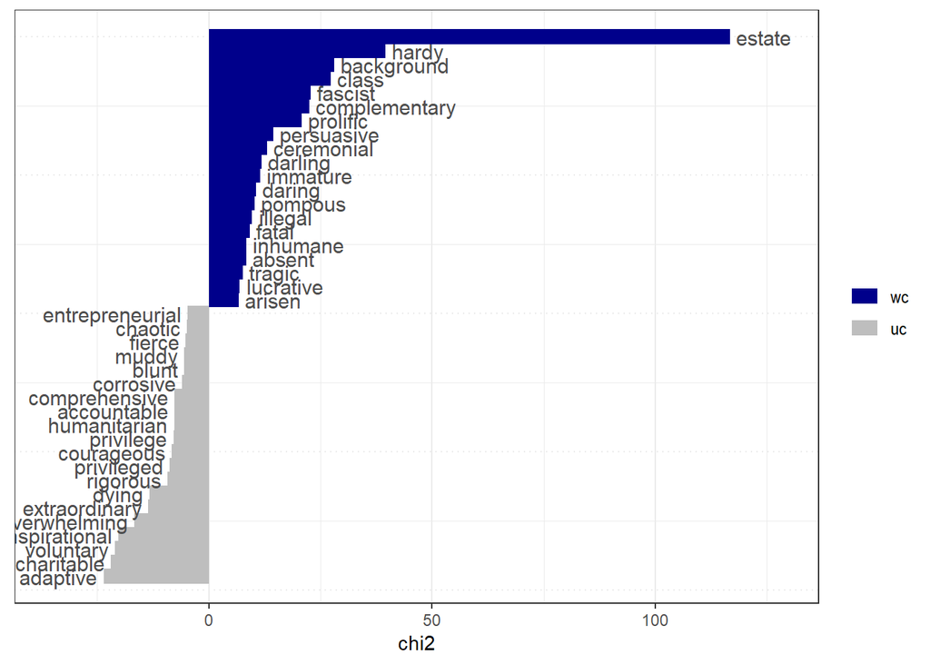

```r
classdict_table <- read.csv("~/Capstone/Dictionaries/GI-ClassPotential.csv",
                            header = T, fill = T, stringsAsFactors = F, blank.lines.skip = T)

classdict <- dictionary(list(
  virtue = classdict_table[,1],
  vice = classdict_table[,2],
  need = classdict_table[,3],
  means = classdict_table[,4],
  persist = classdict_table[,5],
  ought = classdict_table[,6],
  InterPersAdj = classdict_table[,7],
  IndAdj = classdict_table[,8],
  ethics = classdict_table[,9],
  respect = classdict_table[,10],
  skills = classdict_table[,11],
  class_rel = classdict_table[,12]
))

#form into corpus
class_corp <- corpus(class_frame$Article)
docvars(class_corp, "class") <- class_frame$class
docvars(class_corp, "mp") <- class_frame$mp

#use following dfm to apply to textstat_keyness() and kwic() to decide which keys to keep in dictionary
class_dict_res <- dfm(class_corp, groups = "class", remove = stopwords("english"), dictionary = classdict[-c(7,8)]) %>%
  dfm_weight(scheme = "prop")
dfm(class_corp, remove_punct = T, remove = stopwords("english")) %>%
  dfm_select(classdict[c(6:8,12)]) %>%
  dfm_group(groups = "class") %>%
  textstat_keyness("wc", measure = "chi2") %>%
  textplot_keyness(n=20)
```

```r
#estate referring to place growing up, especially for members such as David Lammy, Angela Rayner

#not using need (interest, hope) since this might refer more to how the person presents themself rather than being presented. Or maybe not taken seriously when talking of what country needs, focus on other things. Such as results from 7,8,12: class, background, estate. Not means, no difference. Persist doesnt give much information. Neither does skills.
#Ethics, interesting but leads to just all the bad things each side do.
#keep vice, virtue, adjs, class, respect (interesting)
```

### Using Wordscores to map word usage / types of words used for each gender/class

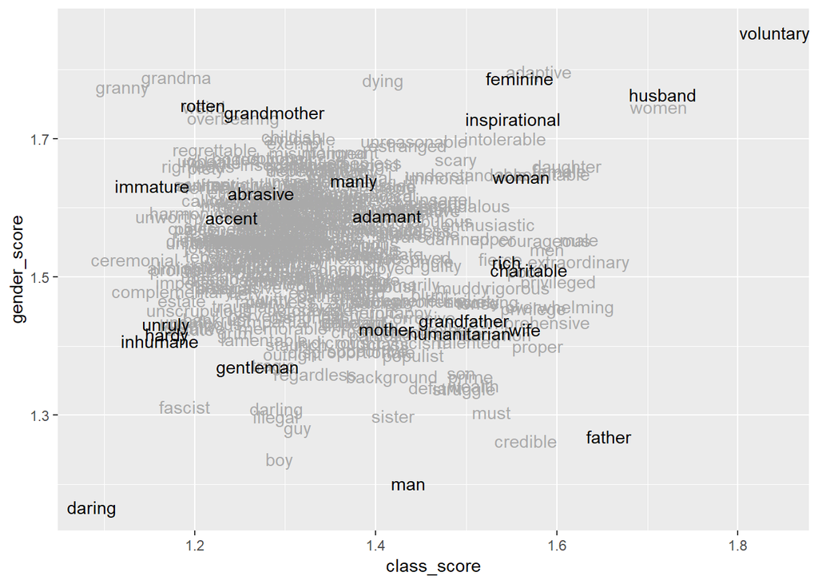

```r
#make shorter gender address dictionary
gendered_words <- c("FEMALE", "FEMININE", "GIRL", "WOMAN", "WOMANLY", "WOMEN", "BOY", "GENTLEMAN", "GUY", "MALE", "MAN ", "MANLY", "MASCULINE", "MEN ")
relations <- c("AUNT", "BRIDE", "COUSIN", "DAUGHTER", "GRANDMA", "GRANDMOTHER", "GRANNY", "MOTHER", "MUM", "MUMMY", "NIECE", "SISTER", "WIDOW", "WIFE", "BROTHER", "DAD", "DADDY", "FATHER", "GRANDAD", "GRANDFATHER", "GRANDPA", "GROOM", "HUSBAND", "NEPHEW", "SON", "UNCLE")
address_dict2 <- dictionary(list(gendered_words = gendered_words, relations = relations))

#make whole dictionary
comb_dict <- dictionary(c(as.list(classdict[c(6:8,12)]), as.list(address_dict2)))
#make dfm for each mp
#1 = wc, men, 2 = uc, fem
class_dfm <- dfm(class_corp, select = comb_dict, groups = "mp") %>%
  dfm_trim(min_termfreq = 5)
docvars(class_dfm, "class") <- c(1,1,1,2,1,1,2,2,1,1,2,2,1,1,2,2)
docvars(class_dfm, "gender") <- c(1,2,1,1,1,1,2,1,2,2,2,2,2,1,2,1)

#apply wordscores
ws_c <- textmodel_wordscores(class_dfm, docvars(class_dfm, "class") , smooth=.5)
ws_g <- textmodel_wordscores(class_dfm, docvars(class_dfm, "gender") , smooth=.5)

#put wordscores into df which will then be plotted
plot_words <- as.data.frame(coef(ws_c))
plot_words$gender_score <- coef(ws_g)
colnames(plot_words)[1] <- "class_score"

#highlight which words most interesting in plot
specific_words <- grepl("feminine|masculine|hardy|daring|unruly|accent|abrasive|rotten|immature|voluntary|charitable|rich|humanitarian|inspirational|husband|wife|mother|father|grandmother|manly|woman|man", rownames(plot_words))

plot_words %>%
  ggplot(aes(x = class_score, y = gender_score)) +
  geom_text(data = plot_words[!specific_words,], label=rownames(plot_words[!specific_words,]), colour = "darkgrey") +
  geom_text(data = plot_words[specific_words,], label=rownames(plot_words[specific_words,]), colour = "black")
```

```r
# let's look at the most discriminant word
sw <- sort(coef(ws_c))
names(head(sw, n=60))
```

```
##  [1] "daring"        "granny"        "ceremonial"    "immature"
##  [5] "inhumane"      "unruly"        "hardy"         "unworthy"
##  [9] "complementary" "prolific"      "grandma"       "almighty"
## [13] "estate"        "fascist"       "unsafe"        "queer"
## [17] "astute"        "imperfect"     "lucrative"     "harmonious"
## [21] "righteous"     "unscrupulous"  "sore"          "rotten"
## [25] "upbeat"        "weird"         "sanitary"      "pompous"
## [29] "piety"         "fertile"       "valiant"       "fragile"
## [33] "callous"       "unseen"        "jobless"       "stale"
## [37] "volatile"      "politeness"    "regrettable"   "bankrupt"
## [41] "unforgettable" "disingenuous"  "ineffectual"   "rosy"
## [45] "widow"         "stubbornly"    "formality"     "fanatical"
## [49] "authoritative" "temporarily"   "despicable"    "accent"
## [53] "regal"         "overbearing"   "reliable"      "drunken"
## [57] "grim"          "amiable"       "bogus"         "avid"
```

```r
tail(sw, n=60)
```

```
##    ineffective          risky          blunt          uncle      wonderful
##       1.449358       1.453332       1.460171       1.462299       1.463787
##        defiant        immoral       fabulous         guilty         insane
##       1.465587       1.466905       1.470243       1.472615       1.472755
##        brother      offensive          scary         damned         unlike
##       1.476935       1.482574       1.488339       1.490673       1.492062
##   humanitarian            son          muddy       struggle    grandfather
##       1.492640       1.494828       1.496193       1.497115       1.497378
##     scandalous understandable       talented          prime        society
##       1.498778       1.499869       1.503316       1.504475       1.506056
##         wealth          tense   enthusiastic        working           must
##       1.507806       1.512974       1.524270       1.524435       1.527657
##          upper         common         fierce    intolerable           rich
##       1.528676       1.534246       1.537525       1.543167       1.544042
##  inspirational       rigorous       feminine          woman           wife
##       1.551586       1.556626       1.558818       1.560293       1.564505
##           poor       credible     charitable  comprehensive      privilege
##       1.564679       1.565647       1.569246       1.570859       1.573941
##         proper       adaptive    accountable     courageous            men
##       1.578808       1.579939       1.584154       1.586022       1.589554
##     privileged         female   overwhelming       daughter  extraordinary
##       1.601448       1.602700       1.603390       1.610600       1.624590
##           male         father          women        husband      voluntary
##       1.624610       1.657359       1.712357       1.717043       1.840656
```